# class17

Matthew Tomaneng

5/29/2018

## Class 17

```r
gal <- read.csv("galExpData.csv")
head(gal)
```

```
##      GENE  COMMON gal1RGexp gal4RGexp gal80Rexp  gal1RGsig  gal4RGsig
## 1 YHR051W    COX6    -0.034     0.111    -0.304 0.37572000 0.01562400
## 2 YHR124W   NDT80    -0.090     0.007    -0.348 0.27146000 0.96433000
## 3 YKL181W    PRS1    -0.167    -0.233     0.112 0.00627120 0.00078940
## 4 YGR072W    UPF3     0.245    -0.471     0.787 0.00041045 0.00075178
## 5 YHL020C    OPI1     0.174    -0.015     0.151 0.00014016 0.71912000
## 6 YGR145W YGR145W     0.387    -0.577    -0.088 0.00537920 0.00827330
##    gal80Rsig
## 1 7.9134e-06
## 2 3.4476e-01
## 3 1.4406e-01
## 4 1.3713e-05
## 5 1.5395e-02
## 6 7.6418e-01
```

# Part 2

```r
#install.packages("igraph")
#install.packages("RCy3")
library("igraph")
source("https://bioconductor.org/biocLite.R")
```

```
## Bioconductor version 3.6 (BiocInstaller 1.28.0), ?biocLite for help
```

```
## A new version of Bioconductor is available after installing the most
##   recent version of R; see http://bioconductor.org/install
```

```r
biocLite("RCy3")
```

```
## BioC_mirror: https://bioconductor.org
```

```
## Using Bioconductor 3.6 (BiocInstaller 1.28.0), R 3.4.4 (2018-03-15).
```

```
## Installing package(s) 'RCy3'
```

```
##
##  /var/folders/1f/zqtc1_cx6pl2xtllm292w4h40000gn/T//Rtmp0QzjgJ/downloaded_packages
```

[output not shown]

```r
#install.packages( c("igraph", "RColorBrewer") )
```

```r
library(RCy3)
```

```r
library(igraph)
library(RColorBrewer)
```

Done Installing all packages

```r
library(RCy3)
cwd <- demoSimpleGraph()
```

```
## [1] "type"
## [1] "lfc"
## [1] "label"
## [1] "count"
## [1] "edgeType"
## [1] "score"
## [1] "misc"
## Successfully set rule.
## Successfully set rule.
## Locked node dimensions successfully even if the check box is not ticked.
## Locked node dimensions successfully even if the check box is not ticked.
## Successfully set rule.
## Successfully set rule.
```

Test Connection to Cytoscape

```r
layoutNetwork(cwd, 'force-directed')

# choose any of the other possible layouts e.g.:
possible.layout.names <- getLayoutNames(cwd)
layoutNetwork (cwd, possible.layout.names[1])

# Test the connection to Cytoscape.
ping(cwd)
```

```
## [1] "It works!"
```

Adjusting the display of the graphs

```r
setVisualStyle(cwd, "Marquee")
```

```
## network visual style has been set to "Marquee"
```

```r
saveImage(cwd,
          file.name="demo" ,
          image.type="png" ,
          h=350)
```

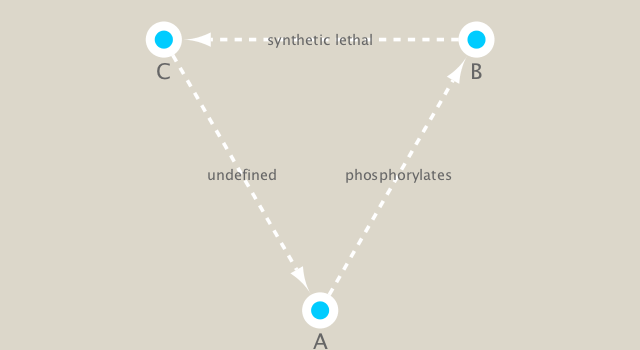

```r
library(knitr)
include_graphics("./demo.png")
```

Other Styles available can be checked using this

```r
styles <- getVisualStyleNames(cwd)
styles
```

```
##  [1] "Nested Network Style" "Minimal"              "BioPAX_SIF"
##  [4] "Solid"                "Sample1"              "size_rank"
##  [7] "Gradient1"            "Curved"               "Sample3"
## [10] "Universe"             "Ripple"               "Directed"
## [13] "Big Labels"           "default black"        "Marquee"
## [16] "Sample2"              "default"              "BioPAX"
```

Set new Styles

```r
#setVisualStyle(cwd, styles[13])
#setVisualStyle(cwd, styles[18])
```

# Section 2

Read data

```r
## scripts for processing located in "inst/data-raw/"
prok_vir_cor <- read.delim("virus_prok_cor_abundant.tsv", stringsAsFactors = FALSE)

## Have a peak at the first 6 rows
head(prok_vir_cor)
```

```
##       Var1          Var2    weight
## 1  ph_1061 AACY020068177 0.8555342
## 2  ph_1258 AACY020207233 0.8055750
## 3  ph_3164 AACY020207233 0.8122517
## 4  ph_1033 AACY020255495 0.8487498
## 5 ph_10996 AACY020255495 0.8734617
## 6 ph_11038 AACY020255495 0.8740782
```

We will start to use Cytoscape

```r
#This data is undirected so that is why we set directed = false
g <- graph.data.frame(prok_vir_cor, directed = FALSE)
```

Double Check the Graph

```r
class(g)
```

```
## [1] "igraph"
```

```r
g
```

```
## IGRAPH 5953c53 UNW- 845 1544 --
## + attr: name (v/c), weight (e/n)
## + edges from 5953c53 (vertex names):
##  [1] ph_1061 --AACY020068177 ph_1258 --AACY020207233
##  [3] ph_3164 --AACY020207233 ph_1033 --AACY020255495
##  [5] ph_10996--AACY020255495 ph_11038--AACY020255495
##  [7] ph_11040--AACY020255495 ph_11048--AACY020255495
##  [9] ph_11096--AACY020255495 ph_1113 --AACY020255495
## [11] ph_1208 --AACY020255495 ph_13207--AACY020255495
## [13] ph_1346 --AACY020255495 ph_14679--AACY020255495
## [15] ph_1572 --AACY020255495 ph_16045--AACY020255495
## + ... omitted several edges
```

[figure not shown]

```r
#First line of data tells us we hae 845 vertices
#UNW tell us the network connection
plot(g)
```

Let’s Fix this Plot

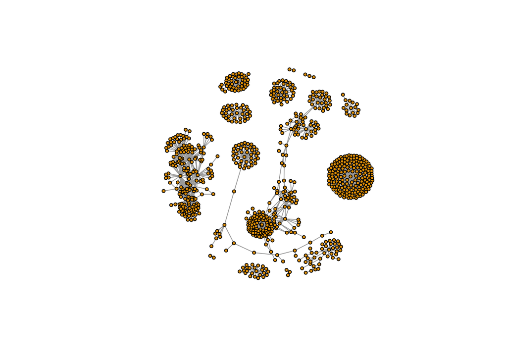

```r
plot(g, vertex.size=3, vertex.label=NA)
```

```r
#Functions V() and E() respectively set vertices to edges into query
```

# Section 3

Lets Learn What the ID’s are

```r
phage_id_affiliation <- read.delim("phage_ids_with_affiliation.tsv")
head(phage_id_affiliation)
```

```
##   first_sheet.Phage_id first_sheet.Phage_id_network phage_affiliation
## 1        109DCM_115804                       ph_775              <NA>
## 2        109DCM_115804                       ph_775              <NA>
## 3        109DCM_115804                       ph_775              <NA>
## 4        109DCM_115804                       ph_775              <NA>
## 5        109DCM_115804                       ph_775              <NA>
## 6        109DCM_115804                       ph_775              <NA>
##   Domain DNA_or_RNA Tax_order Tax_subfamily Tax_family Tax_genus
## 1   <NA>       <NA>      <NA>          <NA>       <NA>      <NA>
## 2   <NA>       <NA>      <NA>          <NA>       <NA>      <NA>
## 3   <NA>       <NA>      <NA>          <NA>       <NA>      <NA>
## 4   <NA>       <NA>      <NA>          <NA>       <NA>      <NA>
## 5   <NA>       <NA>      <NA>          <NA>       <NA>      <NA>
## 6   <NA>       <NA>      <NA>          <NA>       <NA>      <NA>
##   Tax_species
## 1        <NA>
## 2        <NA>
## 3        <NA>
## 4        <NA>
## 5        <NA>
## 6        <NA>
```

```r
#THese are all viruses whih is why there is a lot of missing data
```

```r
bac_id_affi <- read.delim("prok_tax_from_silva.tsv")
head(bac_id_affi)
```

```
##    Accession_ID  Kingdom         Phylum          Class             Order
## 1 AACY020068177 Bacteria    Chloroflexi   SAR202 clade marine metagenome
## 2 AACY020125842  Archaea  Euryarchaeota Thermoplasmata Thermoplasmatales
## 3 AACY020187844  Archaea  Euryarchaeota Thermoplasmata Thermoplasmatales
## 4 AACY020105546 Bacteria Actinobacteria Actinobacteria             PeM15
## 5 AACY020281370  Archaea  Euryarchaeota Thermoplasmata Thermoplasmatales
## 6 AACY020147130  Archaea  Euryarchaeota Thermoplasmata Thermoplasmatales
##              Family             Genus Species
## 1              <NA>              <NA>    <NA>
## 2   Marine Group II marine metagenome    <NA>
## 3   Marine Group II marine metagenome    <NA>
## 4 marine metagenome              <NA>    <NA>
## 5   Marine Group II marine metagenome    <NA>
## 6   Marine Group II marine metagenome    <NA>
```

# Section 4 Add the taxonomic classifications to the network and then send network to Cytoscape

NA’s are a problem in Cytoscape so we change NA’s to not_class

```r
## Create our gene network 'genenet' for cytoscape
genenet.nodes <- as.data.frame(vertex.attributes(g))

## not all have classification, so create empty columns
genenet.nodes$phage_aff <- rep("not_class", nrow(genenet.nodes))
genenet.nodes$Tax_order <- rep("not_class", nrow(genenet.nodes))
genenet.nodes$Tax_subfamily <- rep("not_class", nrow(genenet.nodes))

for (row in seq_along(1:nrow(genenet.nodes))){
  if (genenet.nodes$name[row] %in% phage_id_affiliation$first_sheet.Phage_id_network){
    id_name <- as.character(genenet.nodes$name[row])
    aff_to_add <- unique(subset(phage_id_affiliation,
                                first_sheet.Phage_id_network == id_name,
                                select = c(phage_affiliation,
                                           Tax_order,
                                           Tax_subfamily)))
    genenet.nodes$phage_aff[row] <- as.character(aff_to_add$phage_affiliation)
    genenet.nodes$Tax_order[row] <- as.character(aff_to_add$Tax_order)
    genenet.nodes$Tax_subfamily[row] <- as.character(aff_to_add$Tax_subfamily)
  }
}
```

Do the same for the “proks” data

```r
## do the same for proks
genenet.nodes$prok_king <- rep("not_class", nrow(genenet.nodes))
genenet.nodes$prok_tax_phylum <- rep("not_class", nrow(genenet.nodes))
genenet.nodes$prok_tax_class <- rep("not_class", nrow(genenet.nodes))

for (row in seq_along(1:nrow(genenet.nodes))){
  if (genenet.nodes$name[row] %in% bac_id_affi$Accession_ID){
    aff_to_add <- unique(subset(bac_id_affi,
                                Accession_ID == as.character(genenet.nodes$name[row]),
                                select = c(Kingdom,
                                           Phylum,
                                           Class)))

    genenet.nodes$prok_king[row] <- as.character(aff_to_add$Kingdom)
    genenet.nodes$prok_tax_phylum[row] <- as.character(aff_to_add$Phylum)
    genenet.nodes$prok_tax_class[row] <- as.character(aff_to_add$Class)
  }
}
```

Add to the network the data related to the connections between the organisms, the edge data, and then prepare to send the nodes and edges to Cytoscape using the function cyPlot().

```r
genenet.edges <- data.frame(igraph::as_edgelist(g))
names(genenet.edges) <- c("name.1", "name.2")

genenet.edges$Weight <- igraph::edge_attr(g)[[1]]

genenet.edges$name.1 <- as.character(genenet.edges$name.1)
genenet.edges$name.2 <- as.character(genenet.edges$name.2)
genenet.nodes$name <- as.character(genenet.nodes$name)

ug <- cyPlot(genenet.nodes,genenet.edges)
```

Send network to Cytoscape using RCy3

```r
#We want to get rid of all non used graphs so that we don't overload cytoscape
cy <- CytoscapeConnection()
deleteAllWindows(cy)
```

We will make a new connection with our data

```r
cw <- CytoscapeWindow("Tara oceans",
                      graph = ug,
                      overwriteWindow = TRUE)
#No graph because the displaygraph function was not used
```

Now we will display our graphs on cytoscape

```r
displayGraph(cw)
```

```
## [1] "phage_aff"
## [1] "Tax_order"
## [1] "Tax_subfamily"
## [1] "prok_king"
## [1] "prok_tax_phylum"
## [1] "prok_tax_class"
## [1] "label"
## [1] "Weight"
```

```r
layoutNetwork(cw)
fitContent(cw)
```

# Section 5: Cleaning up the graph in Cytoscape

```r
families_to_colour <- unique(genenet.nodes$prok_tax_phylum)
families_to_colour <- families_to_colour[!families_to_colour %in% "not_class"]
node.colour <- RColorBrewer::brewer.pal(length(families_to_colour), "Set3")
```

Use the colors from Rcolorbrewer to color the nodes in Cytoscape.

```r
setNodeColorRule(cw,
                 "prok_tax_phylum",
                 families_to_colour,
                 node.colour,
                 "lookup",
                 default.color = "#ffffff")
```

```
## Successfully set rule.
```

```r
displayGraph(cw)
```

```
## [1] "phage_aff"
## [1] "Tax_order"
## [1] "Tax_subfamily"
## [1] "prok_king"
## [1] "prok_tax_phylum"
## [1] "prok_tax_class"
## [1] "label"
## [1] "Weight"
```

```r
layoutNetwork(cw)
fitContent(cw)
```

Set node shape to reflect virus or prokaryote

```r
shapes_for_nodes <- c("DIAMOND")

phage_names <- grep("ph_",
                    genenet.nodes$name,
                    value = TRUE)
setNodeShapeRule(cw,
                 "label",
                 phage_names,
                 shapes_for_nodes)
```

```
## Successfully set rule.
```

```r
displayGraph(cw)
```

```
## [1] "phage_aff"
## [1] "Tax_order"
## [1] "Tax_subfamily"
## [1] "prok_king"
## [1] "prok_tax_phylum"
## [1] "prok_tax_class"
## [1] "label"
## [1] "Weight"
```

```r
fitContent(cw)
```

Color edges of phage nodes

```r
setDefaultNodeBorderWidth(cw, 5)
families_to_colour <- c(" Podoviridae",
                        " Siphoviridae",
                        " Myoviridae")
node.colour <- RColorBrewer::brewer.pal(length(families_to_colour),
                          "Dark2")
setNodeBorderColorRule(cw,
                       "Tax_subfamily",
                       families_to_colour,
                       node.colour,
                       "lookup",
                       default.color = "#000000")
```

```
## Successfully set rule.
```

```r
displayGraph(cw)
```

```
## [1] "phage_aff"
## [1] "Tax_order"
## [1] "Tax_subfamily"
## [1] "prok_king"
## [1] "prok_tax_phylum"
## [1] "prok_tax_class"
## [1] "label"
## [1] "Weight"
```

```r
fitContent(cw)
```

SEction 6: Setup a layout to minimize overlap of nodes

```r
getLayoutNames(cw)
```

```
##  [1] "attribute-circle"      "stacked-node-layout"
##  [3] "degree-circle"         "circular"
##  [5] "attributes-layout"     "kamada-kawai"
##  [7] "force-directed"        "cose"
##  [9] "grid"                  "hierarchical"
## [11] "fruchterman-rheingold" "isom"
## [13] "force-directed-cl"
```

```r
getLayoutPropertyNames(cw, layout.name="force-directed")
```

```
## [1] "numIterations"            "defaultSpringCoefficient"
## [3] "defaultSpringLength"      "defaultNodeMass"
## [5] "isDeterministic"          "singlePartition"
```

```r
getLayoutPropertyValue(cw, "force-directed", "defaultSpringLength")
```

```
## [1] 50
```

```r
getLayoutPropertyValue(cw, "force-directed", "numIterations")
```

```
## [1] 100
```

Once we have all the properties we want we can go ahead and set the settings

```r
#setLayoutProperties(cw,
#                    layout.name = force-directed",
#                    list(defaultSpringLength = 20,
#                         "numIterations" = 200))
#layoutNetwork(cw,
#              layout.name = "force-directed")
#fitContent(cw)
layoutNetwork(cw, layout.name = "force-directed")
fitContent(cw)
```

# Section 7. Examine network properties

We will Adjust our nodes

```r
## initiate a new node attribute
ug2 <- initNodeAttribute(graph = ug,
                          "degree",
                          "numeric",
                          0.0)
```

```r
## degree from graph package for undirected graphs not working well,
## so instead using igraph to calculate this from the original graph
nodeData(ug2, nodes(ug2), "degree") <- igraph::degree(g)

cw2 <- CytoscapeWindow("Tara oceans with degree",
                      graph = ug2,
                      overwriteWindow = TRUE)
```

```r
displayGraph(cw2)
```

```
## [1] "phage_aff"
## [1] "Tax_order"
## [1] "Tax_subfamily"
## [1] "prok_king"
## [1] "prok_tax_phylum"
## [1] "prok_tax_class"
## [1] "degree"
## [1] "label"
## [1] "Weight"
```

```r
layoutNetwork(cw2)
```

Size by Degree

```r
#Nodes are now the sizes corresponding tot their number of connections
degree_control_points <- c(min(igraph::degree(g)),
                           mean(igraph::degree(g)),
                           max(igraph::degree(g)))
node_sizes <- c(20,
                20,
                80,
                100,
                110) # number of control points in interpolation mode,
                     # the first and the last are for sizes "below" and "above" the attribute seen.

setNodeSizeRule(cw2,
                "degree",
                degree_control_points,
                node_sizes,
                mode = "interpolate")
```

```
## Locked node dimensions successfully even if the check box is not ticked.
## Locked node dimensions successfully even if the check box is not ticked.
## Successfully set rule.
```

```r
layoutNetwork(cw2,
              "force-directed")
```